# Data Visualization using R

02-06/12/2019

## Day 2

## Today's agenda

### Morning

- Arsenio: **Univariate graphs** - Categorical
- Ben: **Univeriate graphs** - Quantitative
- Joe: **Univariate graphs** - Exercises

### Afternoon

- Ben: **Bivariate graphs** - Introduction
- Arsenio: **Bivariate graphs**|Categorical vs Categorical
- Joe: **Bivariate graphs**|Quantitative vs Quantitative
- Ben: **Bivariate graphs**|Categorical vs Quantitative
- Arsenio: **Bivariate graphs** - Exercises

## Univariate graphs (Arsenio)

- Plot the distribution of data from a single variable
- The variable can be
- Categorical (e.g., sex, marital status, race)
  - typically plotted with a **bar chart**, a **pie chart**, or (less commonly) a **tree map**
- Quantitative (e.g., height, age, weight)
  - typically plotted with a **histogram**, **kernel density plot**, or **dot plot**

## Categorical

### Bar chart – Counts

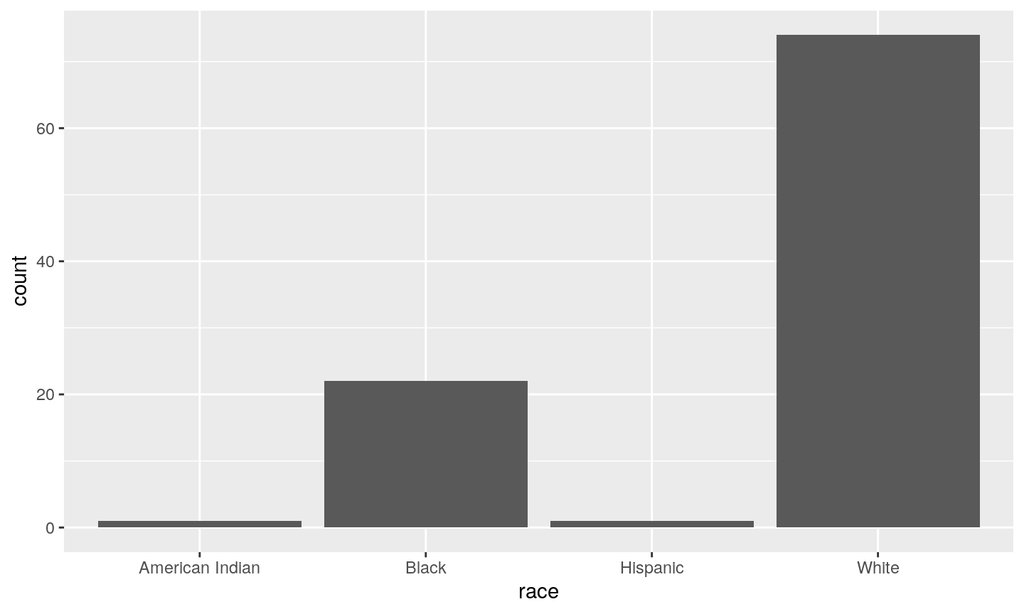

```r
# Importing the data (marriage records of 98 individuals in Mobile County, Alabama)
marriage <- rio::import("data/marriage.rds")
# Plot the distribution of wedding participants' race
ggplot(marriage, aes(x = race)) + geom_bar()
```

## Categorical

### Bar chart – Counts

```r
# Plot the distribution of race with modified colors and labels
ggplot(marriage, aes(x = race)) +
  geom_bar(fill = "lightseagreen",
           color="black") +
  labs(x = "Race",
       y = "Frequency",
       title = "Participants by race")
```

## Categorical

### Bar chart – Counts

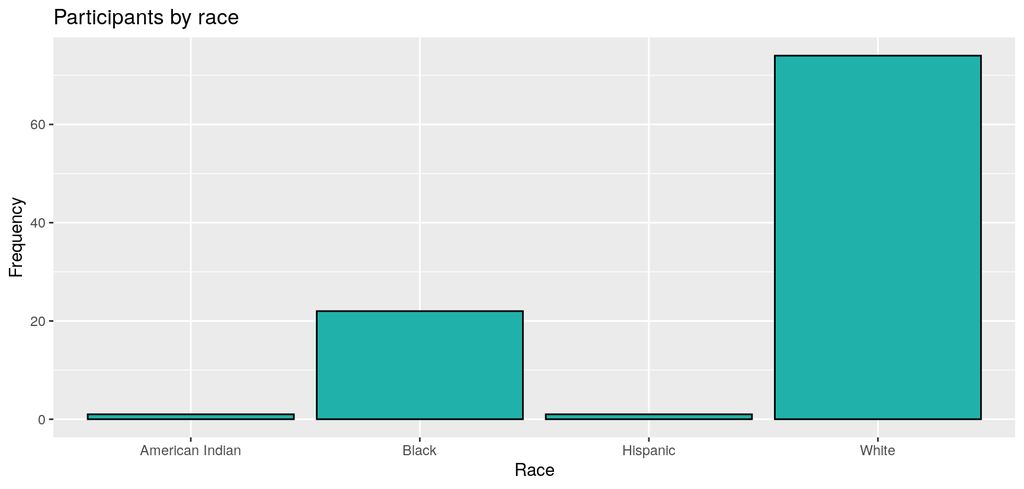

## Categorical

### Bar chart – Percentages

- The code `aes(x=race)` is shortcut for `aes(x = race, y = ..count..)`, where `..count..` is a ggplot calculated variable representing the frequency within each category

```r
# Plot the distribution as percentages
ggplot(marriage, aes(x = race, y = ..count.. / sum(..count..))) +
  geom_bar(fill = "lightseagreen", color="black") +
  labs(x = "Race",
       y = "Frequency",
       title = "Participants by race") +
  scale_y_continuous(labels = scales::percent)
```

## Categorical

### Bar chart – Percentages

[figure not shown]

## Categorical

### Bar chart – Sorting categories

To sort the bars by frequency:

- calculate explicitly the frequencies
- sort the categories by the frequency
- use the option `stat="identity"` in `geom_bar`

```r
# Calculate the frenquency of each race and save
library(dplyr)
racetab <- marriage %>% group_by(race) %>% summarise(n=n()) # or
racetab <- marriage %>% count(race)
```

## Categorical

### Bar chart – Sorting categories

```r
# Plot the bars in ascending order (use `reorder(race, -n)` to sort in descending order)
ggplot(racetab, aes(x = reorder(race, n),
                    y = n)) +
  geom_bar(stat = "identity",
           fill = "lightseagreen",
           color="black") +
  labs(x = "Race",
       y = "Frequency",
       title = "Participants by race")
```

## Categorical

### Bar chart – Sorting categories

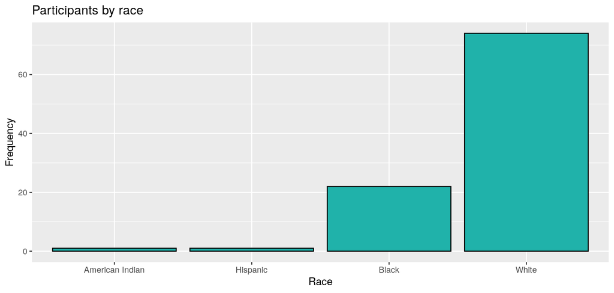

## Categorical

### Bar chart – Labeling bars

```r
# Plot the bars with numeric labels
ggplot(racetab, aes(x = reorder(race, n),
                    y = n)) +
  geom_bar(stat = "identity",
           fill = "lightseagreen",
           color="black") +
  geom_text(aes(label = n),
            vjust=-0.5)+
  labs(x = "Race",
       y = "Frequency",
       title = "Participants by race")
```

- `geom_text` adds the labels, and `vjust` controls vertical justification

## Categorical

### Bar chart – Labeling bars

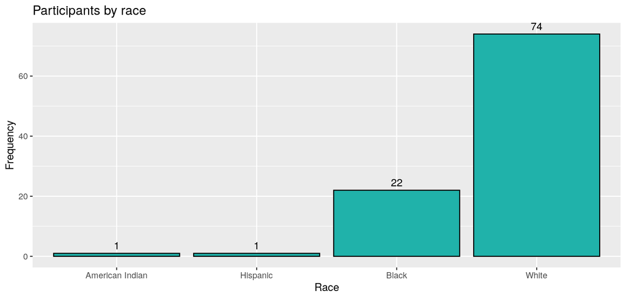

## Categorical

### Bar chart – Labeling bars (%)

```r
library(scales)
# Calculate percentages based on counts previously calculated
racepct <- racetab %>%
  mutate(p = n/sum(n), pct = paste0(round(p*100,1), "%"))

# Plot the bars as percentages, in decending order with bar labels
ggplot(racepct, aes(x = reorder(race, -p), y = p)) +
  geom_bar(stat = "identity", fill = "lightseagreen", color="black") +
  geom_text(aes(label = pct),vjust=-0.25)+
  scale_y_continuous(labels = percent) +
  labs(x = "Race", y = "Proportion", title = "Participants by race")
```

## Categorical

### Bar chart – Labeling bars (%)

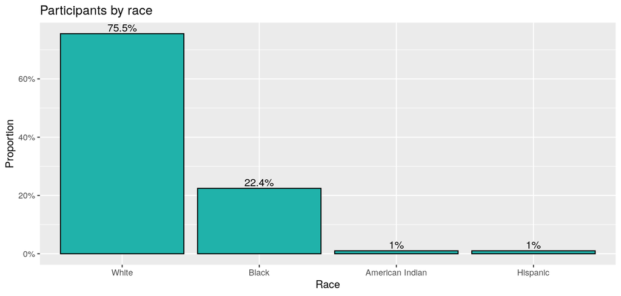

## Categorical

### Bar chart – Overlapping labels

```r
# Bar chart with overlapping labels
ggplot(marriage, aes(x = officialTitle)) +
  geom_bar(fill = "lightseagreen",
           color="black") +
  labs(x = "Officiate",
       y = "Frequency",
       title = "Marriages by officiate")
```

## Categorical

### Bar chart – Overlapping labels

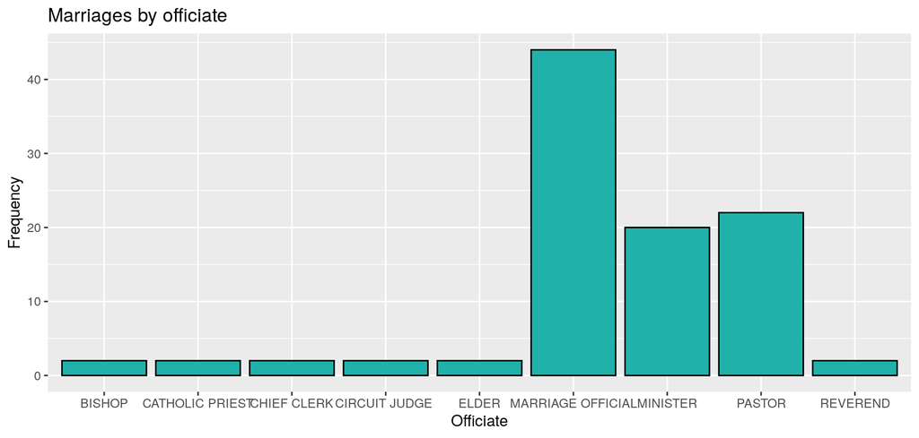

## Categorical

### Bar chart – Overlapping labels

- Solution: flip the x and y axes (`coord_flip()`)

```r
# Horizontal bar chart
ggplot(marriage, aes(x = officialTitle)) +
  geom_bar(fill = "lightseagreen",
           color="black") +
  labs(x = "Officiate",
       y = "Frequency",
       title = "Marriages by officiate") +
  coord_flip()
```

## Categorical

### Bar chart – Overlapping labels

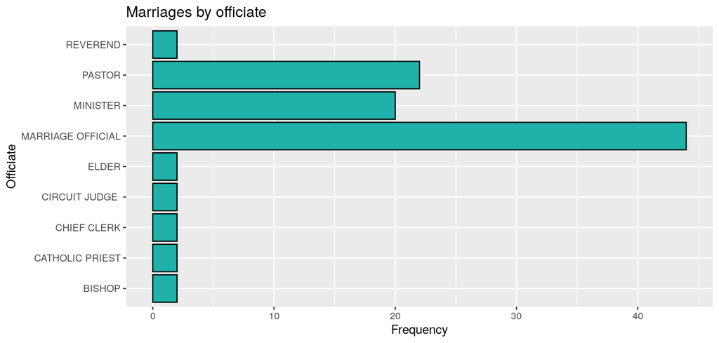

## Categorical

### Bar chart – Overlapping labels

- Alternative solution: rotate the axis labels.

```r
# Bar chart with rotated labels
ggplot(marriage, aes(x = officialTitle)) +
  geom_bar(fill = "lightseagreen",
           color="black") +
  labs(x = "Officiate",
       y = "Frequency",
       title = "Marriages by officiate") +
  theme(axis.text.x = element_text(angle = 45, hjust = 1))
```

## Categorical

### Bar chart – Overlapping labels

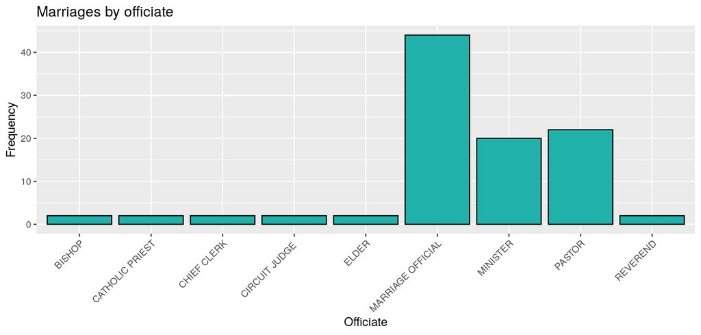

## Categorical

### Pie chart

- Humans are better at distinguishing the length of bars than the volume of pie slices
- If the goal is to compare the frequency of categories, bar charts are better
- If the goal is compare each category with the the whole (e.g., what portion of participants are Hispanic compared to all participants), and the number of categories is small, then pie charts may work

```r
# Prepare data for pie chart
racepie <- marriage %>%
  count(race) %>%
  arrange(desc(race)) %>%
  mutate(pp = round(n*100/sum(n), 1), lab.ypos = cumsum(pp) - 0.5*pp) %>%
  mutate(lab = paste0(race, "\n", round(pp), "%"))
```

## Categorical

### Pie chart – Basic

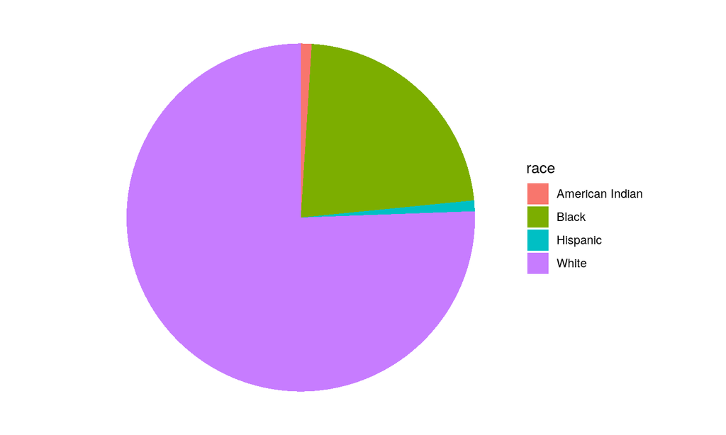

```r
# Create a basic pie chart
ggplot(racepie,aes(x = "", y = pp, fill = race)) +
  geom_bar(width = 1, stat = "identity") +
  coord_polar("y", start = 0, direction = -1) +
  theme_void()
```

## Categorical

### Pie chart – Slice labels

```r
# Create a basic pie chart
ggplot(racepie, aes(x = "", y = pp, fill = race)) +
  geom_bar(width = 1, stat = "identity") +
  geom_text(aes(y = lab.ypos, label = lab), color = "black") +
  coord_polar("y", start = 0, direction = -1) +
  theme_void() +
  theme(legend.position = "FALSE") +
  labs(title = "Participants by race")
```

## Categorical

### Pie chart – Slice labels

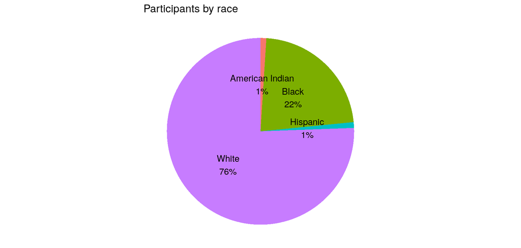

## Categorical

### Tree map

- An alternative to a pie chart
- It handles variables with many categories better that pie chart

```r
library(treemapify)

# Tabulate officialTitle variable
ottm <- marriage %>% count(officialTitle)

# Create a treemap of marriage officials
ggplot(ottm, aes(fill = officialTitle, area = n)) +
  geom_treemap() +
  labs(title = "Marriages by officiate")
```

## Categorical

### Tree map

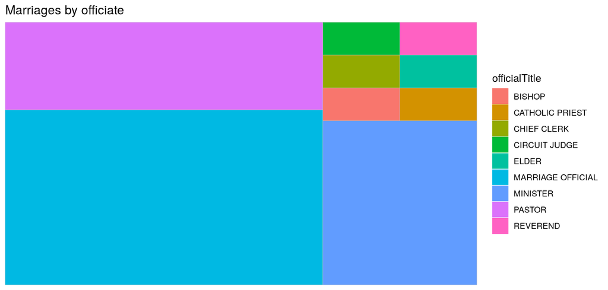

## Categorical

### Tree map – Tile labels

```r
# Create a treemap with tile labels
ggplot(ottm, aes(fill = officialTitle, area = n, label = officialTitle)) +
  geom_treemap() +
  geom_treemap_text(colour = "white", place = "centre") +
  labs(title = "Marriages by officiate") +
  theme(legend.position = "none")
```

## Categorical

### Tree map – Tile labels

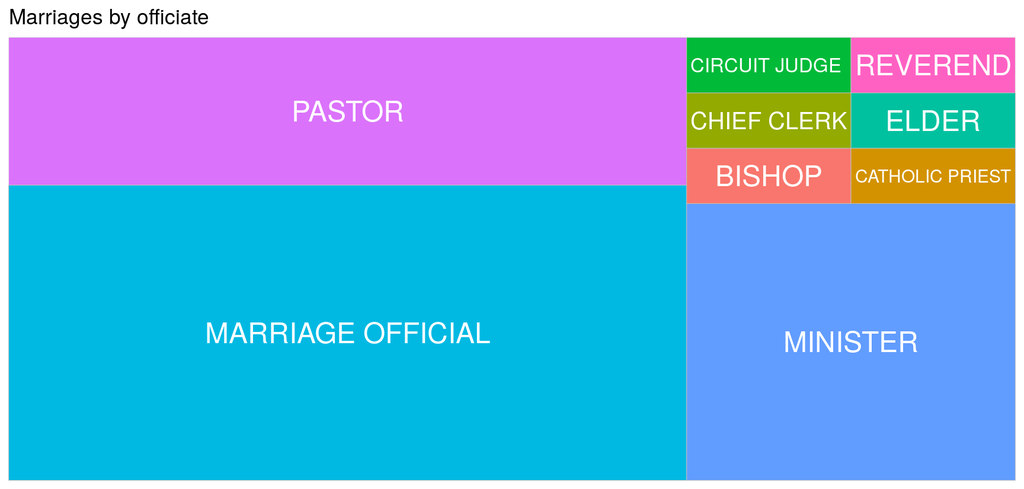

## Univariate graphs

### Quantitative (Ben)

## histogram

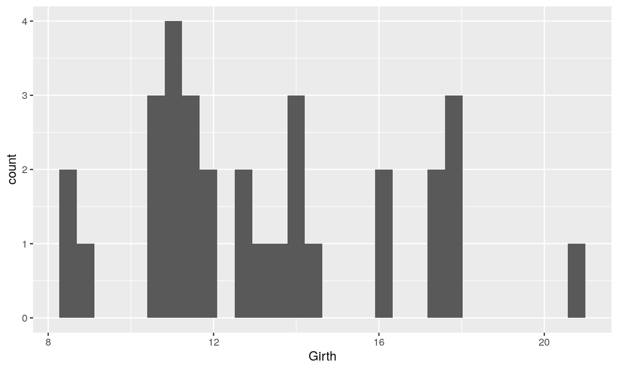

```r
dat <- trees
ggplot(data = dat, aes(Girth)) + geom_histogram()
```

## density

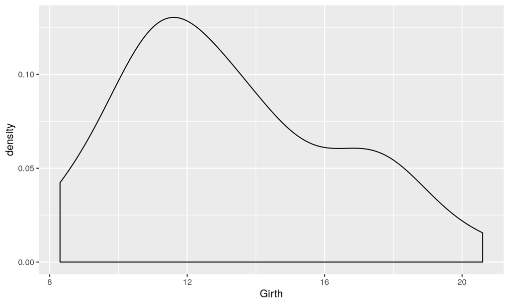

```r
dat <- trees
ggplot(data = dat, aes(Girth)) + geom_density()
```

## boxplot

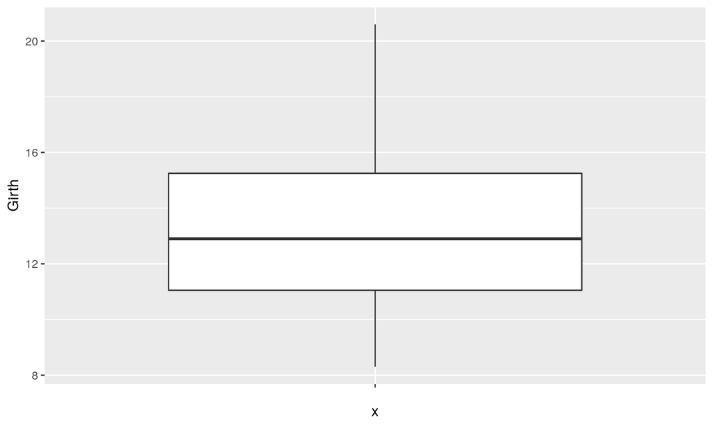

```r
dat <- trees
ggplot(data = dat, aes(x = '', y = Girth)) + geom_boxplot()
```

## Univariate graphs

### Exercises (Joe)

www.databrew.cc/exercises1

## Afternoon

## Bivariate graphs

## Bivariate graphs

### Introduction (Ben)

## Bivariate graphs

### Categorical vs Categorical (Arsenio)

## Categorical vs Categorical

- Typically used graphs: stacked, grouped, and segmented bar charts
- Other: mosaic chart

```r
# Importing the data
mpg <- rio::import('data/mpg.rds')
```

- We are intesrested in the relationship between automobile class and drive type (front-wheel, rear-wheel, or 4-wheel drive)

## Categorical vs Categorical

### Stacked bar chart

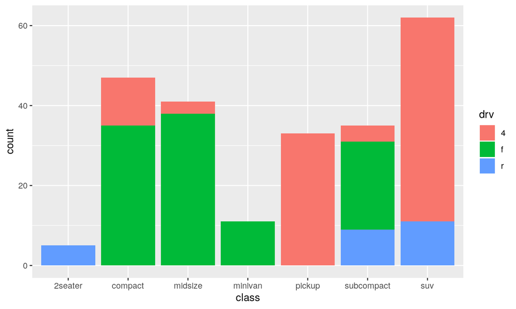

```r
# Stacked bar chart
ggplot(mpg, aes(x = class, fill = drv)) +
  geom_bar()
```

## Categorical vs Categorical

### Grouped bar chart

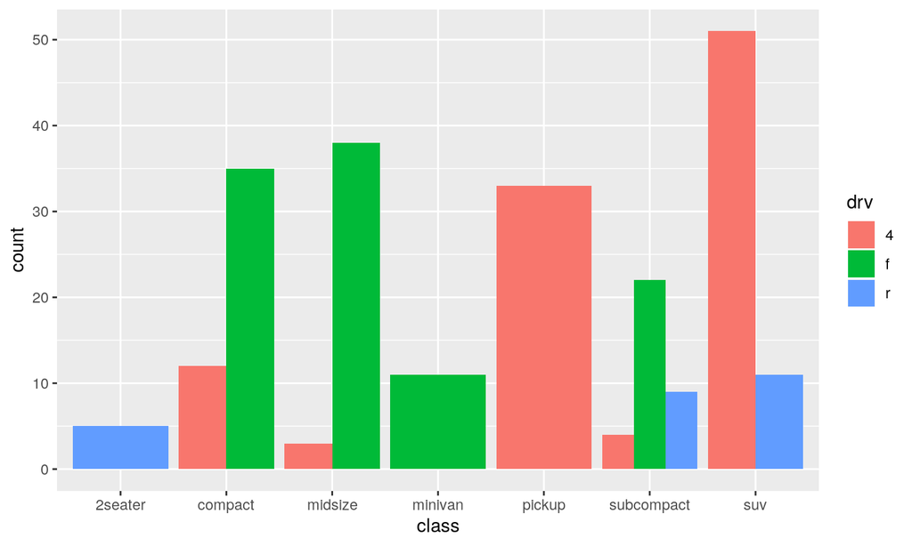

```r
# Grouped bar chart
ggplot(mpg, aes(x = class, fill = drv)) +
  geom_bar(position = "dodge")
```

## Categorical vs Categorical

### Grouped bar chart – Preserving zero count bars

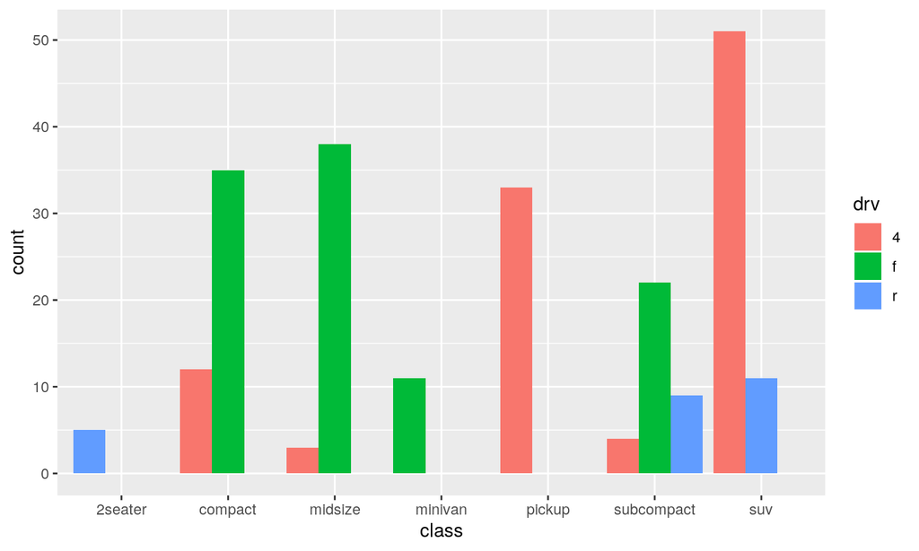

```r
# Grouped bar plot preserving zero count bars
ggplot(mpg, aes(x = class, fill = drv)) +
  geom_bar(position = position_dodge(preserve = "single"))
```

## Categorical vs Categorical

### Segmented bar chart

- A stacked bar plot where each bar represents 100%
- Useful if the goal is to compare the percentage of a category in one variable across each level of another variable

```r
# Bar plot, with each bar representing 100%
ggplot(mpg, aes(x = class, fill = drv)) +
  geom_bar(position = "fill") +
  labs(y = "Proportion")
```

## Categorical vs Categorical

### Segmented bar chart

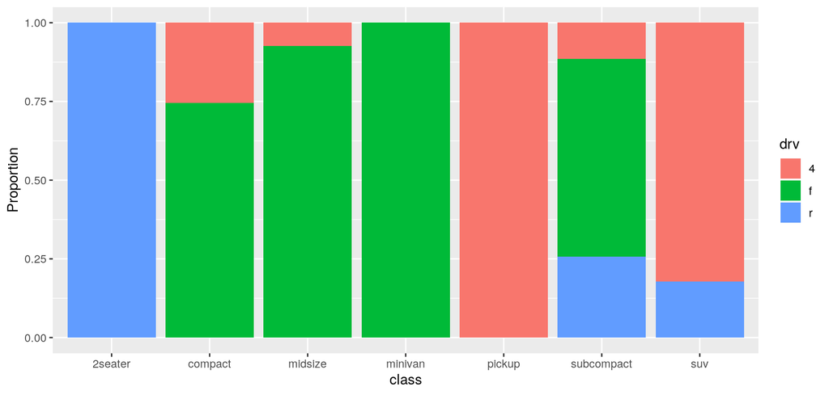

## Categorical vs Categorical

### Segmented bar chart – colour and labeling

```r
# Bar plot, with each bar representing 100%, reordered bars, and better labels and colors
library(scales)
ggplot(mpg, aes(x = factor(class,levels = c("2seater", "subcompact", "compact",
                                            "midsize", "minivan", "suv", "pickup")),
                fill = factor(drv, levels = c("f", "r", "4"),
                              labels = c("front-wheel", "rear-wheel", "4-wheel")))) +
  geom_bar(position = "fill") +
  scale_y_continuous(breaks = seq(0, 1, .2), label = percent) +
  scale_fill_brewer(palette = "Set2") +
  labs(y = "Percent", fill = "Drive Train", x = "Class",
       title = "Automobile Drive by Class")
```

## Categorical vs Categorical

### Segmented bar chart – colour and labeling

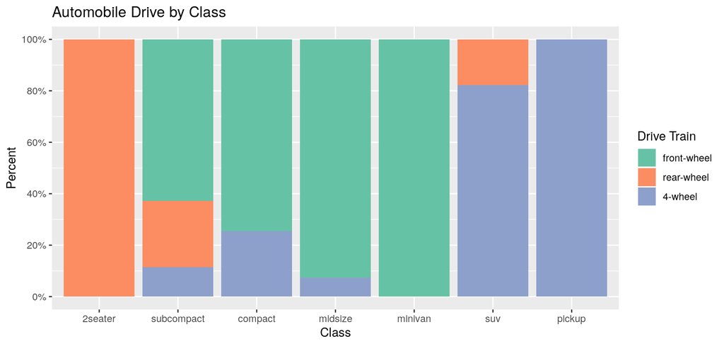

## Categorical vs Categorical

### Segmented bar chart – labeling segments

```r
# Create a summary dataset
library(dplyr)
cds <- mpg %>%
  group_by(class, drv) %>%
  summarize(n = n()) %>%
  mutate(p = n/sum(n),pct = scales::percent(p,accuracy = 0.1))
# Print from the 2nd to 4th rows in HTML table
kable(cds[2:4,])
```

| class | drv | n | p | pct |
| --- | --- | --- | --- | --- |
| compact | 4 | 12 | 0.2553191 | 25.5% |
| compact | f | 35 | 0.7446809 | 74.5% |
| midsize | 4 | 3 | 0.0731707 | 7.3% |

## Categorical vs Categorical

### Segmented bar chart – labeling segments

```r
# Create segmented bar chart adding labels to each segment
ggplot(cds, aes(x = factor(class,levels = c("2seater", "subcompact", "compact",
                                            "midsize", "minivan", "suv", "pickup")),
                y = p,
                fill = factor(drv, levels = c("f", "r", "4"),
                              labels = c("front-wheel", "rear-wheel", "4-wheel")))) +
  geom_bar(stat = "identity", position = "fill") +
  scale_y_continuous(breaks = seq(0, 1, .2), label = percent) +
  geom_text(aes(label = pct), size = 3, position = position_stack(vjust = 0.5)) +
  scale_fill_brewer(palette = "Set2") +
  labs(y = "Percent", fill = "Drive Train", x = "Class",
       title = "Automobile Drive by Class")
```

## Categorical vs Categorical

### Segmented bar chart – labeling segments

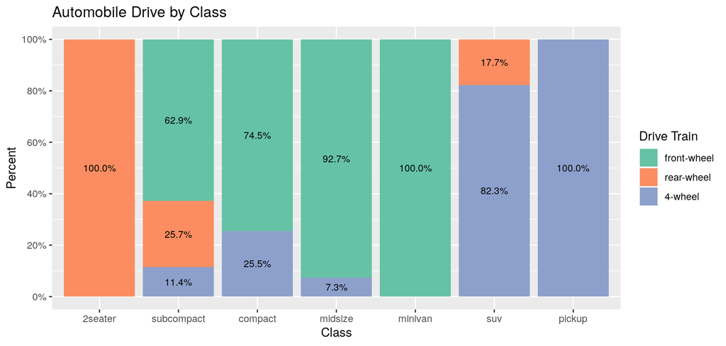

## Categorical vs Categorical

### Mosaic plot

- An alternative to stacked bar charts for displaying the relationship between categorical variables
- It is less commonly used
- As of now, mosaic geomtry function is not available in `ggplot2` package, it is provided by the `ggmosaic` package

```r
library(ggmosaic)
ggplot(mpg)+
  geom_mosaic(aes(x = product(class,drv), fill = drv))+
  theme_minimal()
```

## Categorical vs Categorical

### Mosaic plot

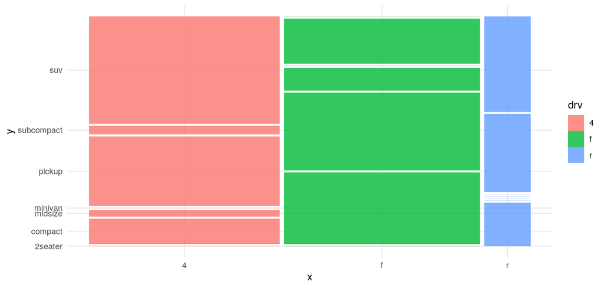

## Bivariate graphs

### Quantitative vs Quantitative (Joe)

```r
data('USArrests')
arrests <- USArrests
```

## Bivariate graphs

### Quantitative vs Quantitative (Joe)

What are the names of the columns?

```r
head(arrests)
```

```
##            Murder Assault UrbanPop Rape
## Alabama      13.2     236       58 21.2
## Alaska       10.0     263       48 44.5
## Arizona       8.1     294       80 31.0
## Arkansas      8.8     190       50 19.5
## California    9.0     276       91 40.6
## Colorado      7.9     204       78 38.7
```

## Bivariate graphs

### Quantitative vs Quantitative (Joe)

How can we visualize the relationship between the percentage of a state which is urban, and the murder rate?

## Bivariate graphs

### Quantitative vs Quantitative (Joe)

How can we visualize the relationship between the Assault rate and the murder rate?

## Bivariate graphs

### Exercises

www.databrew.cc/exercises2

## Bivariate graphs

### Categorical vs Quantitative (Ben)

## barplot

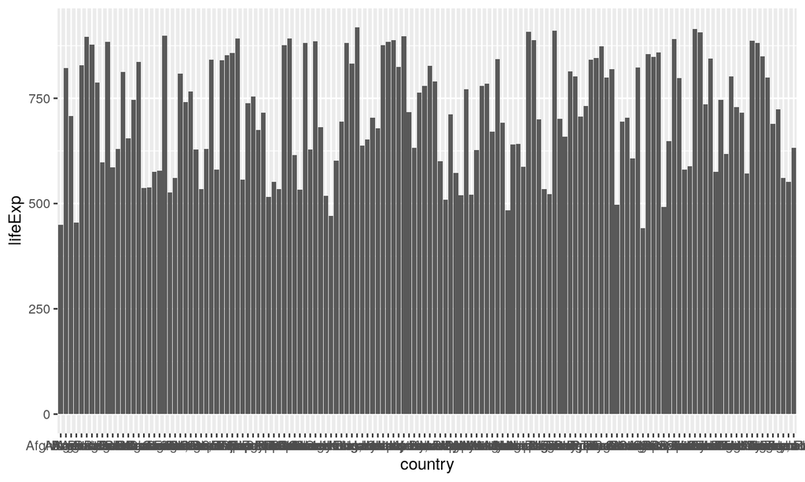

```r
dat <- gapminder

ggplot(data = dat, aes(country, lifeExp)) + geom_bar(stat = 'identity')
```

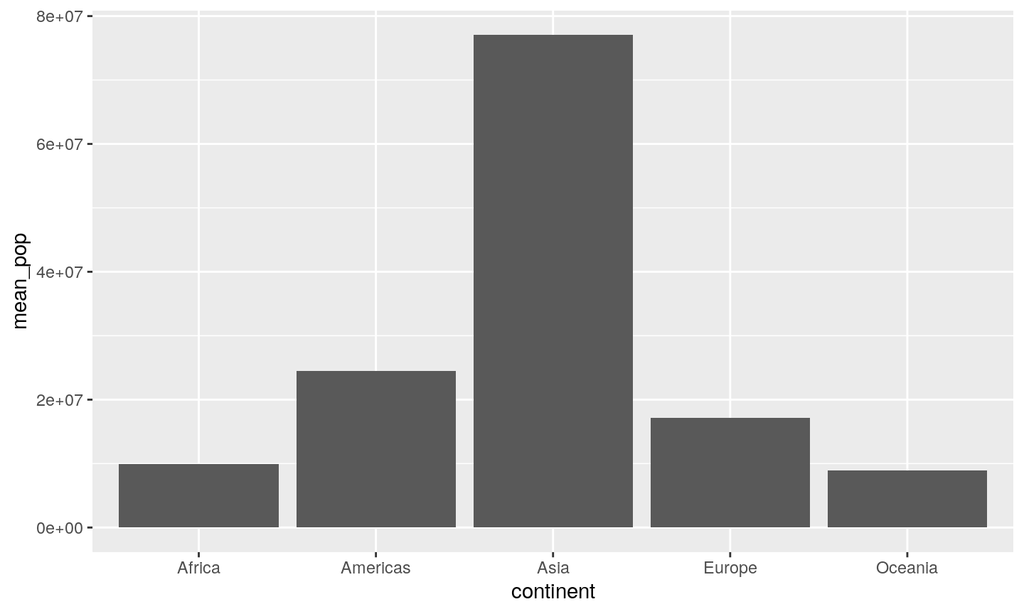

```r
continent <- dat %>% group_by(continent) %>% summarise(mean_pop = mean(pop))

ggplot(data = continent, aes(continent, mean_pop)) + geom_bar(stat = 'identity')
```

## historgram

```r
# ggplot(data = continent, aes(mean_pop))
```

## density

```r
dat <- gapminder
```

## boxplot

```r
dat <- gapminder
```

## Bivariate graphs

### Exercises (Arsenio)

- Pick one of the datasets we used in the examples or one of your own
- Choose pairs of variables and study theirs relationship using suitable graphs

Most of the datasets we used in the examples are availabble in R. You can

- check their details using `help("datasete_name")`

```r
help("mpg")
```

- load them in to R"s global environment using `data(dataset_name, package = package_name`)

```r
data(mpg , package = "ggplot2")
```